# 커피지수_cartography

지역별 카페 브랜드 분포도

- 카페 브랜드별 매장 수 및 지역 분포 조사
- 국내 vs. 해외 브랜드 비교
- 가격대별 브랜드 분포 비교
- ...

박수민  
081219

```python
import pandas as pd
import numpy as np
import seaborn as sns
import platform
import matplotlib.pyplot as plt

%matplotlib inline

path = "c:/Windows/Fonts/malgun.ttf"
from matplotlib import font_manager, rc
if platform.system() == 'Darwin':
    rc('font', family='AppleGothic')
elif platform.system() == 'Windows':
    font_name = font_manager.FontProperties(fname=path).get_name()
    rc('font', family=font_name)
else:
    print('Unknown system')

plt.rcParams['axes.unicode_minus'] = False
```

I. 커피 브랜드 지역별 카운트

- **브랜드 선정**
  1. 여론 조사기업 (주)에스에이컨설팅의 2019년 4월 커피 브랜드 평판조사<sup>**1**</sup>에 의하면 스타벅스는 서비스 만족도, 커피품질 만족도, 브랜드 이미지, 브랜드 신뢰도, 브랜드 인지도 및 구매의향도 등 7분야 중 6개분야의 1위를 차지. 빽다방은 가격 만족도분야 1위 및 브랜드 이미지와 서비스 만족도 공동2위, 10대의 구매의향도 1위 등을 차지했으며 이디야는 20대와 40대의 가격 만족도 1위, 브랜드 이미지와 서비스 만족도 공동 2위 등으로 두 브랜드 모두 전체 최상위권이다.
  2. 한국기업평판연구소의 2019년 7월 빅데이터 분석결과<sup>**2**</sup>에 따르면 커피전문점 브랜드평판 1~5위는 차례로 스타벅스, 투썸플레이스, 이디야, 빽다방, 커피빈이 차지. 지난 1월, 3월, 5월 및 지난 2년의 데이터에 따르면 부동의 1위는 스타벅스이며 그 뒤 상위권을 이디야, 커피빈, 투썸플레이스, 빽다방 등이 번갈아 차지하고 있다. 브랜드평판지수는 소비자 행동분석을 통해 참여가치, 소통가치, 미디어가치, 소셜가치로 분류하고 가중치를 두어 나온 지표이다.
  3. 실제 소비자의 가격대 비교 포스팅<sup>**3**</sup>에 따르면 아메리카노, 카페 라떼 및 기타 에스프레소 음료(카라멜마키아또 등)의 가격비교에서 각각 1500원,2500원, 3000원으로 모든 비교 분야에서 가장 저렴한 브랜드는 빽다방이다. 이디야의 경우 3200원, 3700원, 기타 4000원 미만의 가격으로 총 20여개 조사대상 중 저렴한 브랜드의 한계선으로 여겨진다. 반면 스타벅스의 경우 4100원, 4600원 및 5000원 후반대의 가격으로 중고가 이상 가격대의 대표격이며, 커피빈은 각각 4800원, 5300원, 6000원 이상의 가격대로 가장 고가의 브랜드 중 하나로 보인다.
  4. 위와 같은 정보를 조합하여 기업 브랜드 평판지수가 가장 높은 브랜드 중, 소비자의 인식 및 만족도 또한 최상위이며 다양한 가격대를 대표할 수 있는 브랜드를 선정하고자 하였다. 더하여 국내 브랜드와 해외 브랜드 또한 비교해보고자 국내 브랜드인 빽다방과 이디야, 미국 본사 및 글로벌 기업인 스타벅스와 커피빈을 조사대상으로 선정하였다.
- **지역별 매장 수 조사**
  - **빽다방**  
    소상공인 상권정보 상가업소(2019) 데이터<sup>**4**</sup>. 시각화 목적에 맞게 전처리하여 사용 (코드 및 자료 제공: 임원기)
  - **스타벅스**  
    [Starbucks Coffee Korea](https://www.istarbucks.co.kr/store/store_map.do) 스크래핑. Selenium 사용 (코드 참조: 황성윤 및 JK의 계단 밑 연구실<sup>**5**</sup>)
  - **이디야**  
    [EDIYA COFFEE](https://www.ediya.com/contents/find_store.html) 스크래핑. Selenium 및 도시계획현황:도시지역 인구현황(시군구)(2018) 데이터<sup>**6**</sup> 사용 ('try.. except..' 구문 참조: stackoverflow<sup>**7**</sup>)
  - **커피빈**  
    [COFFEE BEAN Korea](https://www.coffeebeankorea.com/store/store.asp) 스크래핑. Selenium 사용 (Mouse Over actions 코드 참조: All Selenium<sup>**8**</sup>)

```python
ed1 = pd.read_csv("data_soomin/이디야_시군구별카운트_euckr인코딩.csv")
len(ed1)
```

```
215
```

```python
sb1 = pd.read_csv("data_soomin/스벅_시군구별카운트_euckr인코딩.csv")
len(sb1)
```

```
143
```

```python
cb1 = pd.read_csv("data_soomin/커피빈_시군구별카운트_euckr인코딩.csv")
len(cb1)
```

```
58
```

```python
# 제공받은 빽다방 데이터를 위의 세 카페브랜드의 시군구 구분 형식에 맞춰 추가 전처리
# paik = pd.read_csv("참고data/paik_수정.csv", encoding = 'euc-kr')
# paik_ = paik.rename(columns = {"시군구명":"군구"})
# paik_2 = pd.DataFrame(paik_.groupby(paik_.ID).count()['시도명'])
# pk1 = paik_2.rename(columns = {"시도명":"빽다방_빈도"})
# pk1.to_csv("data_soomin/빽다방_시군구별카운트.csv",encoding='utf-8-sig')
# pk1.to_csv("data_soomin/빽다방_시군구별카운트_euckr인코딩.csv")
pk1 = pd.read_csv("data_soomin/빽다방_시군구별카운트_euckr인코딩.csv")
len(pk1)
```

```
139
```

**지역별 전국대비 인구비율 및 도시인구비율 조사**

- 추가적인 비교를 위해 도시계획현황:도시지역 인구현황(시군구)(2018)<sup>**6**</sup>를 전처리하여 사용.

```python
pop = pd.read_csv("data_soomin/시군구별인구비율_euckr인코딩.csv", index_col = 0)
pop = pop.rename(columns = {'지역별도시인구비율':'도시인구비율'})
pop.head()
```

|  | ID | 전국대비인구비율 | 도시인구비율 |
| --- | --- | --- | --- |
| 0 | 서울 종로 | 0.002953 | 100.0 |
| 1 | 서울 중구 | 0.002426 | 100.0 |
| 2 | 서울 용산 | 0.004419 | 100.0 |
| 3 | 서울 성동 | 0.005947 | 100.0 |
| 4 | 서울 광진 | 0.006861 | 100.0 |

```python
cof_merged = pd.merge(pd.merge(pd.merge(pd.merge
                                        ( pk1, ed1, on = 'ID', how = 'outer'),
                                sb1, on="ID", how="outer"),
                         cb1, on="ID", how="outer"),
                      pop, on="ID", how = "outer")
cof_merged = cof_merged.rename(columns = {"이디야_빈도":"이디야", "스벅_빈도":"스벅",
                                         "커피빈_빈도":"커피빈","빽다방_빈도":"빽다방"})

cof_merged.head()
```

|  | ID | 빽다방 | 이디야 | 스벅 | 커피빈 | 전국대비인구비율 | 도시인구비율 |
| --- | --- | --- | --- | --- | --- | --- | --- |
| 0 | 강릉 | 2.0 | 12.0 | 3.0 | NaN | 0.004109 | 87.14 |
| 1 | 거제 | 2.0 | 7.0 | 4.0 | NaN | 0.004834 | 77.12 |
| 2 | 거창 | 2.0 | 1.0 | NaN | NaN | 0.001205 | 65.47 |
| 3 | 경산 | 3.0 | 7.0 | 6.0 | NaN | 0.005038 | 88.59 |
| 4 | 경주 | 2.0 | 22.0 | 7.0 | 1.0 | 0.004956 | 84.34 |

```python
cof_m1 = cof_merged.fillna(0)
cof_m1.head()
```

|  | ID | 빽다방 | 이디야 | 스벅 | 커피빈 | 전국대비인구비율 | 도시인구비율 |
| --- | --- | --- | --- | --- | --- | --- | --- |
| 0 | 강릉 | 2.0 | 12.0 | 3.0 | 0.0 | 0.004109 | 87.14 |
| 1 | 거제 | 2.0 | 7.0 | 4.0 | 0.0 | 0.004834 | 77.12 |
| 2 | 거창 | 2.0 | 1.0 | 0.0 | 0.0 | 0.001205 | 65.47 |
| 3 | 경산 | 3.0 | 7.0 | 6.0 | 0.0 | 0.005038 | 88.59 |
| 4 | 경주 | 2.0 | 22.0 | 7.0 | 1.0 | 0.004956 | 84.34 |

II. 커피 브랜드별 비교 지수

```
>> 비교 지수 계산시, 각 브랜드의 매장수는 해당 브랜드의 전국 매장수에 대해 각 지역이 얼마의 비중을 차지하는가(비례값, 이하 기본 지수라고 명한다)를 계산한 지수로 대체하였다. 이는 브랜드별 전국 매장수가 최대 2300개 이상(이디야)에서 최소 153개(커피빈)까지 차이가 나는 점과 매장 수가 본사의 규모 및 투자크기 등 고려하기 어려운 변수에 크게 영향을 받을 것을 감안한 것이다.
```

- **기본 지수 계산**
  - **지수_pk**  
    지역별 빽다방 매장 수 / 전국 빽다방 매장 수
  - **지수_ed**  
    지역별 이디야 매장 수 / 전국 이디야 매장 수
  - **지수_sb**  
    지역별 스타벅스 매장 수 / 전국 스타벅스 매장 수
  - **지수_cb**  
    지역별 커피빈 매장 수 / 전국 커피빈 매장 수

```python
tot_paik = cof_m1['빽다방'].sum() ; cof_m1['지수_pk'] = cof_m1['빽다방'] /tot_paik
tot_ed = cof_m1['이디야'].sum() ; cof_m1['지수_ed'] = cof_m1['이디야'] /tot_ed
tot_sb = cof_m1['스벅'].sum() ; cof_m1['지수_sb'] = cof_m1['스벅'] /tot_sb
tot_cb = cof_m1['커피빈'].sum() ; cof_m1['지수_cb'] = cof_m1['커피빈'] /tot_cb

cof_m1.head()
```

|  | ID | 빽다방 | 이디야 | 스벅 | 커피빈 | 전국대비인구비율 | 도시인구비율 | 지수_pk | 지수_ed | 지수_sb | 지수_cb |
| --- | --- | --- | --- | --- | --- | --- | --- | --- | --- | --- | --- |
| 0 | 강릉 | 2.0 | 12.0 | 3.0 | 0.0 | 0.004109 | 87.14 | 0.003390 | 0.004741 | 0.002294 | 0.000000 |
| 1 | 거제 | 2.0 | 7.0 | 4.0 | 0.0 | 0.004834 | 77.12 | 0.003390 | 0.002766 | 0.003058 | 0.000000 |
| 2 | 거창 | 2.0 | 1.0 | 0.0 | 0.0 | 0.001205 | 65.47 | 0.003390 | 0.000395 | 0.000000 | 0.000000 |
| 3 | 경산 | 3.0 | 7.0 | 6.0 | 0.0 | 0.005038 | 88.59 | 0.005085 | 0.002766 | 0.004587 | 0.000000 |
| 4 | 경주 | 2.0 | 22.0 | 7.0 | 1.0 | 0.004956 | 84.34 | 0.003390 | 0.008692 | 0.005352 | 0.006536 |

- **국산 브랜드 vs. 해외 브랜드 비교**
  - **지수_국내해외**  
    (지수_pk + 지수_ed) / (지수_sb + 지수_cb)

```python
cof_m1['지수_해외국내'] =  (cof_m1['지수_sb'] + cof_m1['지수_cb'])/(cof_m1['지수_pk'] + cof_m1['지수_ed'])
cof_m1.head()
```

[output not shown]

- **가격대별 브랜드 분포도 비교**
  - **지수_최저가**  
    지수_pk / (지수_ed + 지수_sb + 지수_cb)
  - **지수_최고가**  
    지수_cb / (지수_pk + 지수_ed + 지수_sb)
  - **지수_고가**  
    지수_sb / (지수_pk + 지수_ed + 지수_cb)

```python
cof_m1['지수_최저가'] = cof_m1['지수_pk'] / (cof_m1['지수_ed'] + cof_m1['지수_sb'] + cof_m1['지수_cb'])
cof_m1['지수_최고가'] = cof_m1['지수_cb'] / (cof_m1['지수_pk'] + cof_m1['지수_ed'] + cof_m1['지수_sb'])
cof_m1['지수_고가'] = cof_m1['지수_sb'] / (cof_m1['지수_pk'] + cof_m1['지수_ed'] + cof_m1['지수_cb'])
cof_m1.head()
```

|  | ID | 빽다방 | 이디야 | 스벅 | 커피빈 | 전국대비인구비율 | 도시인구비율 | 지수_pk | 지수_ed | 지수_sb | 지수_cb | 지수_국내해외 | 지수_최저가 | 지수_최고가 | 지수_고가 | 지수_해외국내 |
| --- | --- | --- | --- | --- | --- | --- | --- | --- | --- | --- | --- | --- | --- | --- | --- | --- |
| 0 | 강릉 | 2.0 | 12.0 | 3.0 | 0.0 | 0.004109 | 87.14 | 0.003390 | 0.004741 | 0.002294 | 0.000000 | 3.545133 | 0.481867 | 0.000000 | 0.282077 | 0.282077 |
| 1 | 거제 | 2.0 | 7.0 | 4.0 | 0.0 | 0.004834 | 77.12 | 0.003390 | 0.002766 | 0.003058 | 0.000000 | 2.012860 | 0.582064 | 0.000000 | 0.496805 | 0.496805 |
| 2 | 거창 | 2.0 | 1.0 | 0.0 | 0.0 | 0.001205 | 65.47 | 0.003390 | 0.000395 | 0.000000 | 0.000000 | inf | 8.579661 | 0.000000 | 0.000000 | 0.000000 |
| 3 | 경산 | 3.0 | 7.0 | 6.0 | 0.0 | 0.005038 | 88.59 | 0.005085 | 0.002766 | 0.004587 | 0.000000 | 1.711398 | 0.691533 | 0.000000 | 0.584318 | 0.584318 |
| 4 | 경주 | 2.0 | 22.0 | 7.0 | 1.0 | 0.004956 | 84.34 | 0.003390 | 0.008692 | 0.005352 | 0.006536 | 1.016355 | 0.164716 | 0.374902 | 0.287447 | 0.983909 |

```python
cof_m1.to_csv("data_soomin/커피지수및인구비율_euckr인코딩.csv")
cof_m1.to_csv("data_soomin/커피지수및인구비율.csv", encoding = 'utf-8-sig')
```

III. 시각화

- **Cartogram_버거지수 변형 및 데이터 전처리**
  - 블로거 및 현 프로젝트 참고교재 저자인 PinkWink가 블로거 혜식의 버거지수 시각화에서 차용 및 변형한 데이터를 사용. 시각화하고자 하는 데이터에 맞춰 행정구가 추가된 지역ID(수원~부천 등)를 변경하였으며 해당 작업은 엑셀파일에서 이루어져 코드에는 반영되지 않았다.

```python
draw_korea_raw = pd.read_excel('data_soomin/draw_korea_수정.xlsx',
                               encoding="euc-kr")
draw_korea_raw_stacked = pd.DataFrame(draw_korea_raw.stack())
draw_korea_raw_stacked.reset_index(inplace=True)
draw_korea_raw_stacked.rename(columns={'level_0':'y', 'level_1':'x', 0:'ID'},
                              inplace=True)
draw_korea = draw_korea_raw_stacked

draw_korea.head()
```

|  | y | x | ID |
| --- | --- | --- | --- |
| 0 | 0 | 7 | 철원 |
| 1 | 0 | 8 | 화천 |
| 2 | 0 | 9 | 양구 |
| 3 | 0 | 10 | 고성(강원) |
| 4 | 1 | 3 | 양주 |

```python
BORDER_LINES = [
    [(5, 1), (5,2), (7,2), (7,3), (11,3), (11,0)], # 인천
    [(5,4), (5,5), (2,5), (2,7), (4,7), (4,9), (7,9),
     (7,7), (9,7), (9,5), (10,5), (10,4), (5,4)], # 서울
    [(1,7), (1,8), (3,8), (3,10), (10,10), (10,7),
     (12,7), (12,6), (11,6), (11,5), (12, 5), (12,4),
     (11,4), (11,3)], # 경기도
    [(8,10), (8,11), (6,11), (6,12)], # 강원도
    [(12,5), (13,5), (13,4), (14,4), (14,5), (15,5),
     (15,4), (16,4), (16,2)], # 충청북도
    [(16,4), (17,4), (17,5), (16,5), (16,6), (19,6),
     (19,5), (20,5), (20,4), (21,4), (21,3), (19,3), (19,1)], # 전라북도
    [(13,5), (13,6), (16,6)], # 대전시
    [(13,5), (14,5)], #세종시
    [(21,2), (21,3), (22,3), (22,4), (24,4), (24,2), (21,2)], #광주
    [(20,5), (21,5), (21,6), (23,6)], #전라남도
    [(10,8), (12,8), (12,9), (14,9), (14,8), (16,8), (16,6)], #충청북도
    [(14,9), (14,11), (14,12), (13,12), (13,13)], #경상북도
    [(15,8), (17,8), (17,10), (16,10), (16,11), (14,11)], #대구
    [(17,9), (18,9), (18,8), (19,8), (19,9), (20,9), (20,10), (21,10)], #부산
    [(16,11), (16,13)], #울산
#     [(9,14), (9,15)],
    [(27,5), (27,6), (25,6)],
]
```

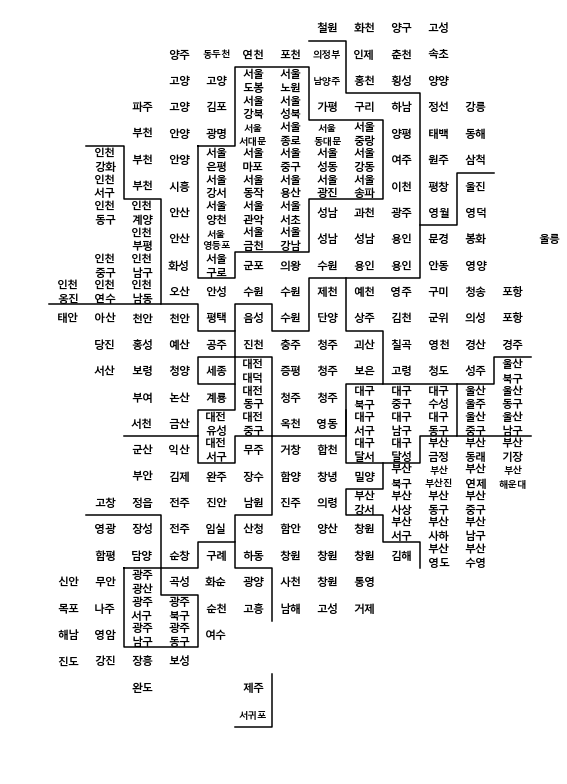

```python
plt.figure(figsize=(8, 11))
# 지역 이름 표시
for idx, row in draw_korea.iterrows():

    # 광역시는 구 이름이 겹치는 경우가 많아서 시단위 이름도 같이 표시한다.
    # (중구, 서구)
    if len(row['ID'].split())==2:
        dispname = '{}\n{}'.format(row['ID'].split()[0], row['ID'].split()[1])
    elif row['ID'][:2]=='고성':
        dispname = '고성'
    else:
        dispname = row['ID']

    # 서대문구, 서귀포시 같이 이름이 3자 이상인 경우에 작은 글자로 표시한다.
    if len(dispname.splitlines()[-1]) >= 3:
        fontsize, linespacing = 9.5, 1.5
    else:
        fontsize, linespacing = 11, 1.2

    plt.annotate(dispname, (row['x']+0.5, row['y']+0.5), weight='bold',
                 fontsize=fontsize, ha='center', va='center',
                 linespacing=linespacing)

# 시도 경계 그린다.
for path in BORDER_LINES:
    ys, xs = zip(*path)
    plt.plot(xs, ys, c='black', lw=1.5)

plt.gca().invert_yaxis()
#plt.gca().set_aspect(1)

plt.axis('off')

plt.tight_layout()
plt.show()
```

```python
# ID가 호환되지 않아 의도치않게 지워지는 데이터가 없도록 확인한다.

print(set(draw_korea['ID'].unique()) - set(cof_m1['ID'].unique()))
print(set(cof_m1['ID'].unique()) - set(draw_korea['ID'].unique()) )
```

```
set()
{'인천 미추'}
```

```python
# 인천 미추(미추홀구)의 경우 사용하고자 하는 cartogram 의 ID 에 존재하지 않으므로 삭제한다.

cof_m2 = cof_m1.drop(cof_m1[cof_m1['ID'] == '인천 미추'].index)
set(cof_m2['ID'].unique()) - set(draw_korea['ID'].unique())
```

```
set()
```

```python
# cartogram을 그리기 위해 draw_korea 데이터프레임과 카페브랜드 데이터프레임을 합치도록 한다.

cof_m3 = pd.merge(cof_m2, draw_korea, how = 'left', on = ['ID'])
cof_m3.head()
```

|  | ID | 빽다방 | 이디야 | 스벅 | 커피빈 | 전국대비인구비율 | 도시인구비율 | 지수_pk | 지수_ed | 지수_sb | 지수_cb | 지수_국내해외 | 지수_최저가 | 지수_최고가 | 지수_고가 | 지수_해외국내 | y | x |
| --- | --- | --- | --- | --- | --- | --- | --- | --- | --- | --- | --- | --- | --- | --- | --- | --- | --- | --- |
| 0 | 강릉 | 2.0 | 12.0 | 3.0 | 0.0 | 0.004109 | 87.14 | 0.003390 | 0.004741 | 0.002294 | 0.000000 | 3.545133 | 0.481867 | 0.000000 | 0.282077 | 0.282077 | 3 | 11 |
| 1 | 거제 | 2.0 | 7.0 | 4.0 | 0.0 | 0.004834 | 77.12 | 0.003390 | 0.002766 | 0.003058 | 0.000000 | 2.012860 | 0.582064 | 0.000000 | 0.496805 | 0.496805 | 22 | 8 |
| 2 | 거창 | 2.0 | 1.0 | 0.0 | 0.0 | 0.001205 | 65.47 | 0.003390 | 0.000395 | 0.000000 | 0.000000 | inf | 8.579661 | 0.000000 | 0.000000 | 0.000000 | 16 | 6 |
| 3 | 경산 | 3.0 | 7.0 | 6.0 | 0.0 | 0.005038 | 88.59 | 0.005085 | 0.002766 | 0.004587 | 0.000000 | 1.711398 | 0.691533 | 0.000000 | 0.584318 | 0.584318 | 12 | 11 |
| 4 | 경주 | 2.0 | 22.0 | 7.0 | 1.0 | 0.004956 | 84.34 | 0.003390 | 0.008692 | 0.005352 | 0.006536 | 1.016355 | 0.164716 | 0.374902 | 0.287447 | 0.983909 | 12 | 12 |

```python
def drawKorea(targetData, blockedMap, cmapname):
    gamma = 0.75

    whitelabelmin = (max(blockedMap[targetData]) -
                                     min(blockedMap[targetData]))*0.25 + \
                                                                min(blockedMap[targetData])

    datalabel = targetData

    vmin = min(blockedMap[targetData])
    vmax = max(blockedMap[targetData])

    mapdata = blockedMap.pivot_table(index='y', columns='x', values=targetData)
    masked_mapdata = np.ma.masked_where(np.isnan(mapdata), mapdata)

    plt.figure(figsize=(9, 11))
    plt.pcolor(masked_mapdata, vmin=vmin, vmax=vmax, cmap=cmapname,
               edgecolor='#aaaaaa', linewidth=0.5)

    # 지역 이름 표시
    for idx, row in blockedMap.iterrows():
        # 광역시는 구 이름이 겹치는 경우가 많아서 시단위 이름도 같이 표시한다.
        #(중구, 서구)
        if len(row['ID'].split())==2:
            dispname = '{}\n{}'.format(row['ID'].split()[0], row['ID'].split()[1])
        elif row['ID'][:2]=='고성':
            dispname = '고성'
        else:
            dispname = row['ID']

        # 서대문구, 서귀포시 같이 이름이 3자 이상인 경우에 작은 글자로 표시한다.
        if len(dispname.splitlines()[-1]) >= 3:
            fontsize, linespacing = 10.0, 1.1
        else:
            fontsize, linespacing = 11, 1.

        annocolor = 'white' if row[targetData] > whitelabelmin else 'black'
        plt.annotate(dispname, (row['x']+0.5, row['y']+0.5), weight='bold',
                     fontsize=fontsize, ha='center', va='center', color=annocolor,
                     linespacing=linespacing)

    # 시도 경계 그린다.
    for path in BORDER_LINES:
        ys, xs = zip(*path)
        plt.plot(xs, ys, c='black', lw=2)

    plt.gca().invert_yaxis()

    plt.axis('off')

    cb = plt.colorbar(shrink=.1, aspect=10)
    cb.set_label(datalabel)

    plt.tight_layout()
    plt.show()
```

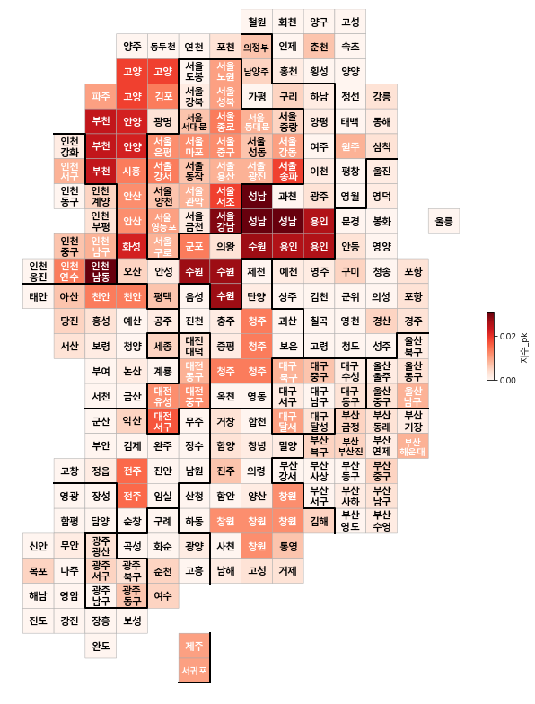

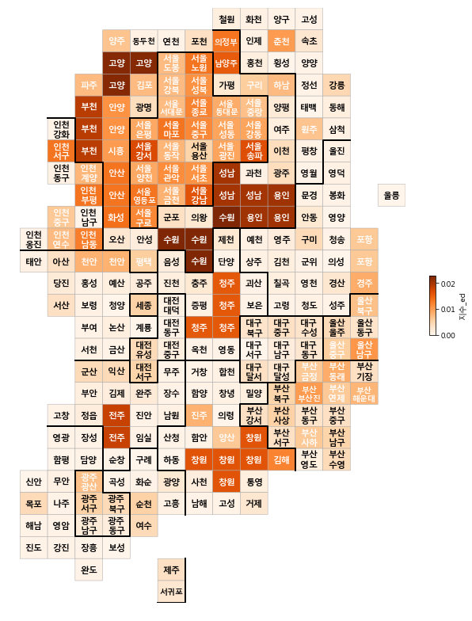

```python
drawKorea('지수_pk', cof_m3, 'Reds')
drawKorea('지수_ed', cof_m3, 'Oranges')
```

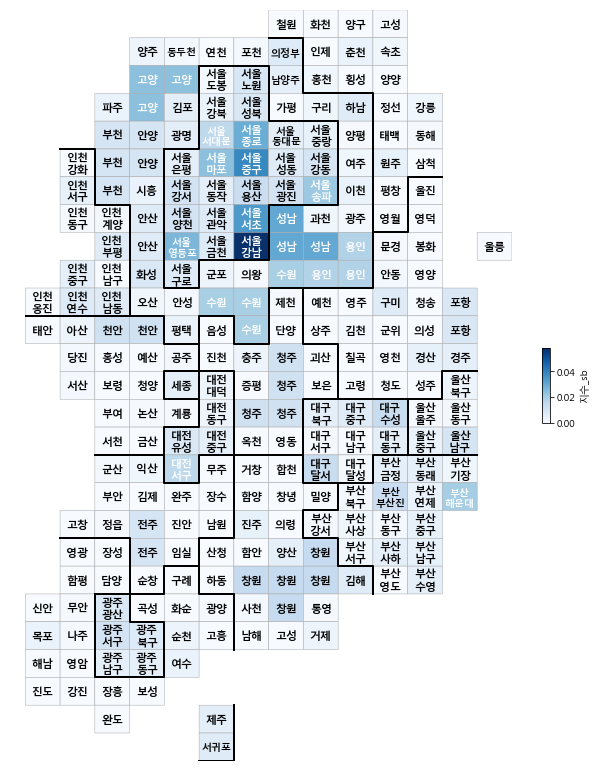

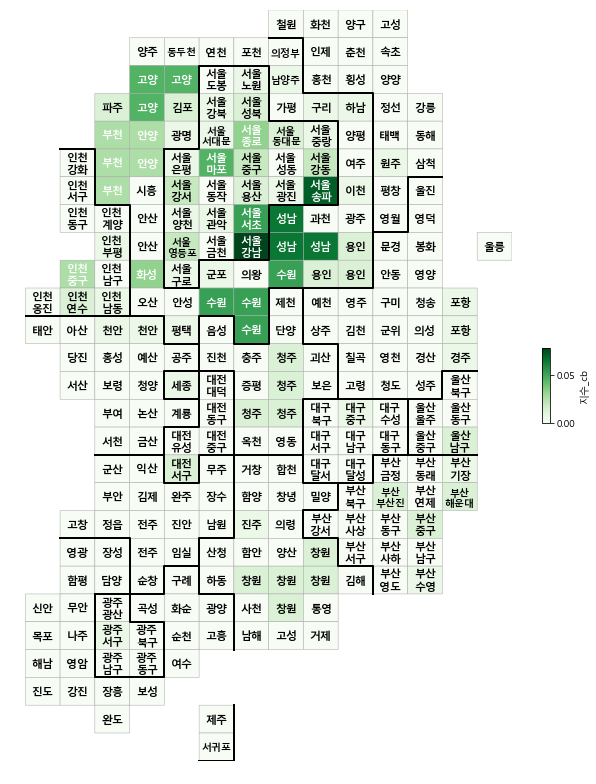

```python
drawKorea('지수_sb', cof_m3, 'Blues')
drawKorea('지수_cb', cof_m3, 'Greens')
```

- **해외 vs. 국내 브랜드**  
  >> 일부 지역의 inf로 인해 그래프가 올바르게 그려지지 않을 수 있어 np.inf를 np.nan 으로 변경한다. nan(그래프 상 흰 색 셀)의 경우, 해당 지역에 외국브랜드(스타벅스, 커피빈)와 비교대상인 국내 브랜드가 존재하지 않았음 으로 이해할 수 있다.  
  그래프에 따르면 서울 중심지역(강남, 마포, 서초 등) 및 일부 광역시의 중심지(대구 수성구, 부산 해운대, 인천 중구, 광주 남구 등)에는 해외브랜드의 집중도가 국내브랜드에 비해 월등히 높은 것으로 보인다. 반면 대부분의 일반 지역에서는 국내브랜드의 집중도가 높다.  
  계산에는 매장 수가 아닌 전국 매장수에 대비 지역별 비례값을 사용하였으므로, 이 결과는 '해외 브랜드 매장이 다수 위치한' 지역이 아닌, 해당 해외 브랜드에서 매장 개점 및 운영에 대해 타지역에 비해 중요시하는 지역을 파악하는 것으로 한다.

```python
cof_m3_1 = cof_m3.replace([np.inf, -np.inf], np.nan)
cof_m3_1.head()
```

|  | ID | 빽다방 | 이디야 | 스벅 | 커피빈 | 전국대비인구비율 | 도시인구비율 | 지수_pk | 지수_ed | 지수_sb | 지수_cb | 지수_국내해외 | 지수_최저가 | 지수_최고가 | 지수_고가 | 지수_해외국내 | y | x |
| --- | --- | --- | --- | --- | --- | --- | --- | --- | --- | --- | --- | --- | --- | --- | --- | --- | --- | --- |
| 0 | 강릉 | 2.0 | 12.0 | 3.0 | 0.0 | 0.004109 | 87.14 | 0.003390 | 0.004741 | 0.002294 | 0.000000 | 3.545133 | 0.481867 | 0.000000 | 0.282077 | 0.282077 | 3 | 11 |
| 1 | 거제 | 2.0 | 7.0 | 4.0 | 0.0 | 0.004834 | 77.12 | 0.003390 | 0.002766 | 0.003058 | 0.000000 | 2.012860 | 0.582064 | 0.000000 | 0.496805 | 0.496805 | 22 | 8 |
| 2 | 거창 | 2.0 | 1.0 | 0.0 | 0.0 | 0.001205 | 65.47 | 0.003390 | 0.000395 | 0.000000 | 0.000000 | NaN | 8.579661 | 0.000000 | 0.000000 | 0.000000 | 16 | 6 |
| 3 | 경산 | 3.0 | 7.0 | 6.0 | 0.0 | 0.005038 | 88.59 | 0.005085 | 0.002766 | 0.004587 | 0.000000 | 1.711398 | 0.691533 | 0.000000 | 0.584318 | 0.584318 | 12 | 11 |
| 4 | 경주 | 2.0 | 22.0 | 7.0 | 1.0 | 0.004956 | 84.34 | 0.003390 | 0.008692 | 0.005352 | 0.006536 | 1.016355 | 0.164716 | 0.374902 | 0.287447 | 0.983909 | 12 | 12 |

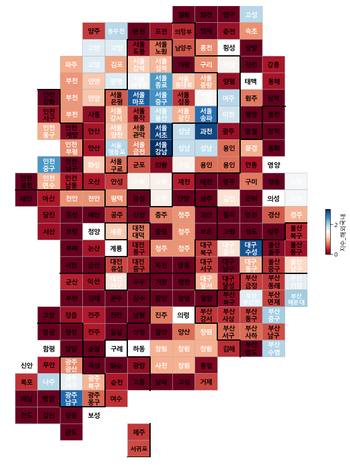

```python
drawKorea('지수_해외국내', cof_m3_1, 'RdBu')
```

- **가격대 비교**  
  가격대별 대표적인 브랜드가 타 브랜드들과 비교하여 어떠한 분포를 보이고 있는지 파악하고자 했다.  
  **최저가 브랜드로 뽑은 빽다방의 경우, 서울, 부산 및 대부분 대도시의 중심지역 등 발달한 지역일수록 타브랜드에 비해 밀도가 떨어지는 것으로 보인다. 반면 최고가 브랜드로 꼽힌 커피빈의 경우 정반대의 양상을 보이는데, 비교대상인 세 브랜드에 비해 서울과 부산 등의 대도시에 유의하게 밀집함을 볼 수 있다. 고가 브랜드로 조사된 스타벅스는 커피빈과 비슷하게 타지역에 비해서 서울, 부산 등 대도시에 집중하는 추이가 있으나 뚜렷하지 않고, 오히려 의외일 수 있는 고성, 여주, 과천 등에서 강세로 나타나며 대구, 광주 등 기타 광역시에 보다 집중하고 있다.**

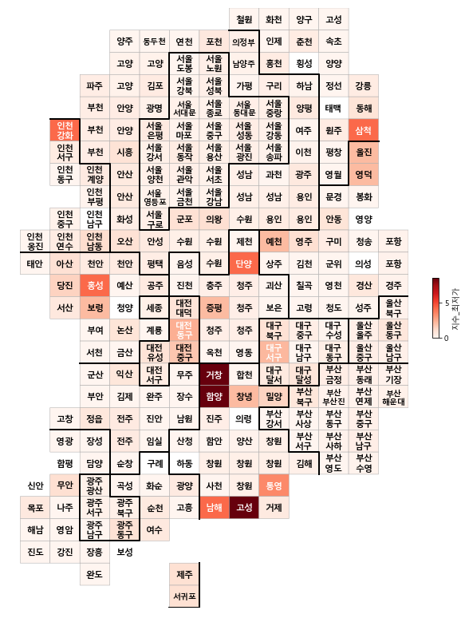

```python
drawKorea('지수_최저가', cof_m3_1, 'Reds') #빽다방
```

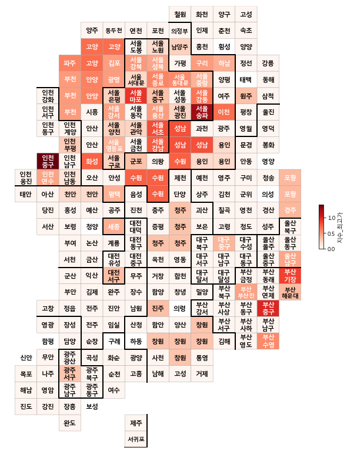

```python
drawKorea('지수_최고가', cof_m3_1, 'Reds') #커피빈
```

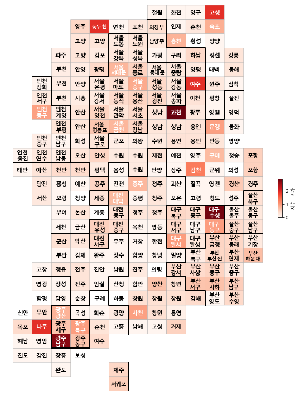

```python
drawKorea('지수_고가', cof_m3_1, 'Reds') #스타벅스
```

- **전국 대비 지역별 인구 밀집도 및 도시 인구 비율**  
  앞의 브랜드별 지역 집중분포도와 이하 지역별 인구 밀집도 및 도시인구비율을 비교하면 몇가지 흥미로운 양상을 파악할 수 있다.  
  예를 들어 위의 기본 분포 그래프 중 빽다방과 이디야의 경우 서울 및 부산의 중심지역보다 경기, 창원 등에서 강한 집중도를 보였는데, 이는 전국 인구 대비 비율과 비교할 때 **비교적 저렴하며 매장운영에 있어 보다 자유로운(가맹점, 제휴점 등 가능) 국내 카페 브랜드가 대도시 근교 주거 밀집지역의 상권에 집중하고 있는 것**이 아닌가 추정된다.  
  이제 스타벅스와 커피빈을 각각 비교한 기본 분포 그래프와 해외vs.국내 브랜드 비교 및 고가 브랜드 비교 그래프 등을 비교해 보자. 이들을 파악해보자면 **한국에서는 직영점만 운영하는 까다로운 조건을 가지며 고가의 서비스를 제공하는 두 브랜드의 경우, 한 매장에서 얻을 수 있는 수익의 극대화를 위해 주간에 인구의 유동이 활발하고 사무 및 여러 경제활동이 밀집하여 카페 소비량이 높을만한 대도시의 중심지역에 집중하는 것**으로 보인다.

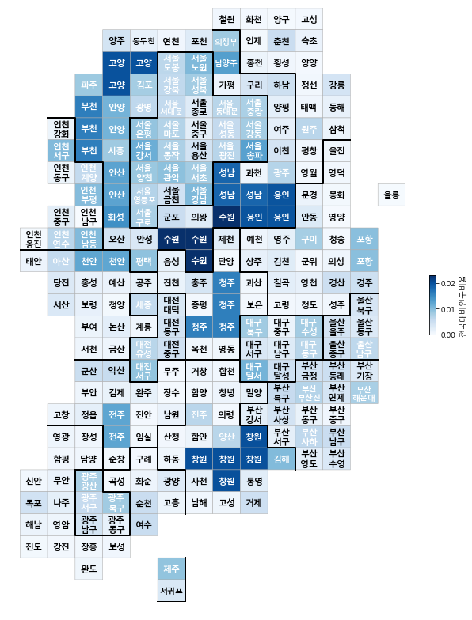

```python
drawKorea('전국대비인구비율', cof_m3_1, 'Blues') # 전국 대비 인구 밀집도
```

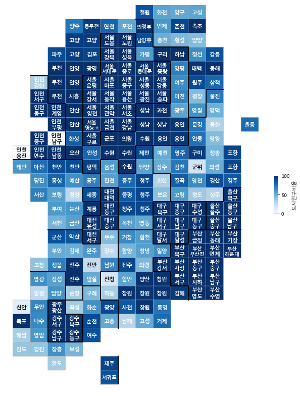

```python
drawKorea('도시인구비율', cof_m3_1, 'Blues') # 도시화율
```

- *상관관계 파악 및 추가 시각화__향후 추가계획*
  - **pairplot & heatmap**  
    지역별 전국대비 인구 밀집도와 도시 인구 비율을 독립변수로, 기타 지수를 종속변수로 놓아 상관관계를 분석해보고자 한다.

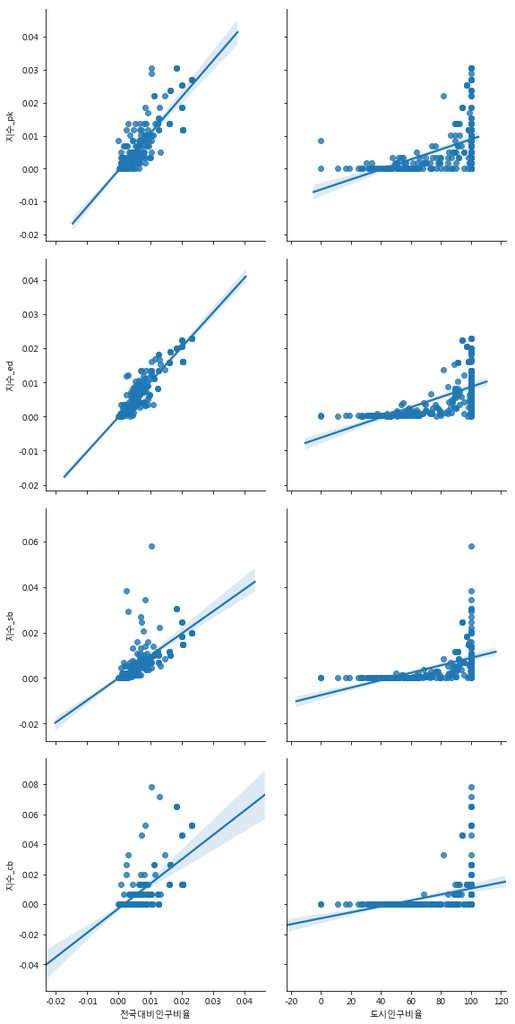

```python
sns.pairplot(cof_m3_1, x_vars = ["전국대비인구비율","도시인구비율"],
             y_vars =["지수_pk", "지수_ed", "지수_sb", "지수_cb"] , kind="reg", height = 4)
plt.show()
```

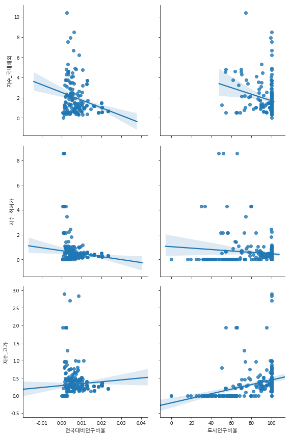

```python
sns.pairplot(cof_m3_1, x_vars = ["전국대비인구비율","도시인구비율"],
             y_vars =["지수_국내해외", "지수_최저가", "지수_고가"] , kind="reg", height = 4)
plt.show()
```

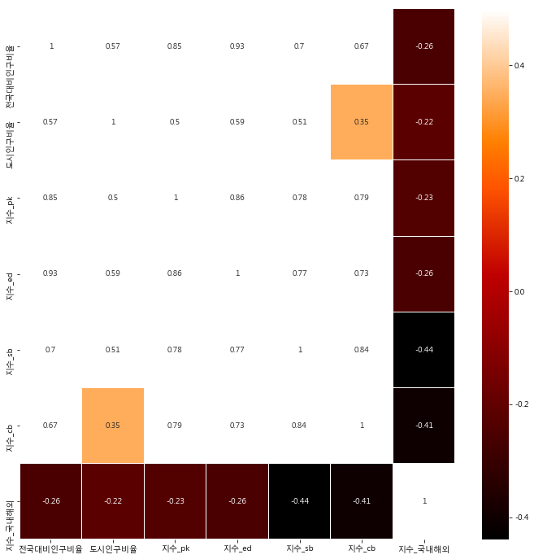

```python
cof_m3_2 = cof_m3_1[['전국대비인구비율','도시인구비율','지수_pk', '지수_ed', '지수_sb','지수_cb', '지수_국내해외']]

plt.figure(figsize=(12,12))
sns.heatmap(cof_m3_2.corr(), linewidths=0.1, vmax = 0.5, cmap=plt.cm.gist_heat, linecolor="white",annot=True)
plt.show()
```

- *Folium 활용__향후 추가 계획*
  - *위의 시각화에서 추정된 지역별 특성과 카페 브랜드의 타겟 상권의 관계를 면밀히 파악하고자 한다. 이를 위해 표본 지역을 전국이 아닌 개별 지역(서울과 경기 등)에 한정하여 고급상권 및 사무실 밀집지역, 주거 밀집지역, 기타 용도지역 등으로 나누어 보도록 한다.*

```python
import folium
import json
geo_path = '02. skorea_municipalities_geo_simple.json'
geo_str = json.load(open(geo_path, encoding='utf-8'))
```

참조 링크

1. [커피 브랜드 평판도 설문 조사 결과](http://blog.naver.com/PostView.nhn?blogId=ljhjh123&logNo=221519985231&categoryNo=0&parentCategoryNo=26&viewDate=&currentPage=1&postListTopCurrentPage=1&from=search), 에스에이컨설팅
2. [커피전문점 브랜드 2019년 7월 빅데이터 분석결과](http://rekorea.net/bbs/board.php?bo_table=repu6&wr_id=1031), 한국기업평판연구소
3. ['아메리카노' 가장 싼 곳은? ...커피 브랜드 20곳 가격비교](https://post.naver.com/viewer/postView.nhn?volumeNo=21423417&memberNo=6132524), 이투데이
4. [상가(상권)정보, 공공데이터포털](https://www.data.go.kr/dataset/15012005/fileData.do), 정보화전략실
5. [<문과의 파이썬> 셀레니움(Selenium)-(1)](https://brunch.co.kr/@jk-lab/18), JK의 계단 밑 연구실
6. [도시지역 인구현황(시군구)](http://kosis.kr/search/search.do),한국토지주택공사,「도시계획현황」
7. [Check if any alert exists using selenium with python](https://stackoverflow.com/questions/19003003/check-if-any-alert-exists-using-selenium-with-python), stackoverflow
8. [Mouse Over actions using Python Selenium WebDriver](http://allselenium.info/mouse-over-actions-using-python-selenium-webdriver/), ALL SELENIUM